# Shawn Kalish - Individual Assignment #3

### Regression with ARIMA Errors Laboratory.

#### (Total 40 pts.)

#### Due: Dec. 2 (before midnight)

As a newly minted MSBA you start working for a large resort hotel managing 1,877 rooms. A tour operator that you frequently do business with has requested a block of 60 rooms for Aug. 22. As this operator will pay a discounted rate for each room, your manager is uncertain if she should give this block of rooms to the tour operator, and she has asked you to provide model-based support for this decision.

Although the price is discounted and it may prevent you from selling some of these rooms at the regular price, if you reject this request, any empty rooms will not generate any revenue and you would have incurred an opportunity cost by not selling these rooms.

After judicious consideration of the economic trade offs in the Newsvendor model, you and your manager determine that the block should be assigned to the tour operator only if the probability of your organic demand (excluding the room block in question) is smaller than 67% (i.e., you are on track to achieve a 67% service level).

To address the booking question you examine the following data set and proceed to develop a demand forecast model.

The data set **Booking Exercise.csv** consists of daily observations of the following six variables:

- **DATE**: Calendar date corresponding to each observation.
- **DOW**: Index (1-7) to indicate the day of the week each **DATE** corresponds to. This is redundant and it is eliminated below.
- **DEMAND**: Number of rooms actually sold on each **DATE**.
- **TUESDAY.BOOK**: Number of rooms booked on the Tuesday of the previous week for each day of the forthcoming week. This variable is used as an input to inform the forecasts of **DEMAND** for each day of the forthcoming week.
- **PICKUP.RATIO**: This is a calculated variable obtained as **PICKUP.RATIO = DEMAND/TUESDAY.BOOK** historically as **DEMAND** is observed. Because of this is a calculated relationship you can use either **PICKUP.RATIO** or **TUESDAY.BOOK** but you cannot use both variables simultaneously in a model to predict **DEMAND**.
- **DOW.INDEX**: This is a pre-calculated indicator of day-of-the-week demand intensity. This is obtained by the Hotel using information beyond what it is contained in this data set.

1. (15 pt.) Fit (a) an ETS, (b) a plain ARIMA, (c) a linear regression model to predict **DEMAND** as a function of **TUESDAY.BOOK**, (d) a non-seasonal regression model with ARIMA errors using **TUESDAY.BOOK** and **DOW.INDEX** as explanatory variables, and (e) a seasonal regression model with ARIMA errors using only **TUESDAY.BOOK** as an explanatory variable. You may use automatic model selection to fit an initial model, but especially in cases (d) and (e) you should modify the automatically fitted models when appropriate.

```
## Series: DEMAND
## Model: ETS(A,N,A)
##   Smoothing parameters:
##     alpha = 0.9998969
##     gamma = 0.0001000471
##
##   Initial states:
##      l[0]      s[0]     s[-1]    s[-2]    s[-3]    s[-4]     s[-5]    s[-6]
##  1465.946 -95.33474 -132.6443 95.16317 147.1579 87.43041 -210.9891 109.2166
##
##   sigma^2:  42400.13
##
##      AIC     AICc      BIC
## 1326.011 1328.905 1350.670
```

```
## Series: DEMAND
## Model: ARIMA(1,0,0)(2,0,0)[7] w/ mean
##
## Coefficients:
##          ar1    sar1    sar2  constant
##       0.7322  0.4746  0.2035   123.243
## s.e.  0.0726  0.1086  0.1273    18.864
##
## sigma^2 estimated as 47972:  log likelihood=-592.53
## AIC=1195.07   AICc=1195.81   BIC=1207.4
```

```
##
## Call:
## lm(formula = DEMAND ~ TUESDAY.BOOK, data = X)
##
## Residuals:
##     Min      1Q  Median      3Q     Max
## -296.95  -78.79   14.88   99.72  334.48
##
## Coefficients:
##               Estimate Std. Error t value Pr(>|t|)
## (Intercept)  521.74996   48.84698   10.68   <2e-16 ***
## TUESDAY.BOOK   0.69559    0.03323   20.93   <2e-16 ***
## ---
## Signif. codes:  0 '***' 0.001 '**' 0.01 '*' 0.05 '.' 0.1 ' ' 1
##
## Residual standard error: 126.9 on 85 degrees of freedom
## Multiple R-squared:  0.8375, Adjusted R-squared:  0.8356
## F-statistic: 438.1 on 1 and 85 DF,  p-value: < 2.2e-16
```

```
##
## Call:
## lm(formula = log(DEMAND) ~ log(TUESDAY.BOOK), data = X)
##
## Residuals:
##       Min        1Q    Median        3Q       Max
## -0.271925 -0.047061  0.003045  0.060137  0.188192
##
## Coefficients:
##                   Estimate Std. Error t value Pr(>|t|)
## (Intercept)        2.48712    0.22945   10.84   <2e-16 ***
## log(TUESDAY.BOOK)  0.66671    0.03181   20.96   <2e-16 ***
## ---
## Signif. codes:  0 '***' 0.001 '**' 0.01 '*' 0.05 '.' 0.1 ' ' 1
##
## Residual standard error: 0.09397 on 85 degrees of freedom
## Multiple R-squared:  0.8378, Adjusted R-squared:  0.8359
## F-statistic: 439.2 on 1 and 85 DF,  p-value: < 2.2e-16
```

```
## Series: DEMAND
## Model: LM w/ ARIMA(1,1,0) errors
##
## Coefficients:
##           ar1  TUESDAY.BOOK  DOW.INDEX
##       -0.1748        0.8442   919.1318
## s.e.   0.1098        0.0385   144.7827
##
## sigma^2 estimated as 11503:  log likelihood=-522.58
## AIC=1053.17   AICc=1053.66   BIC=1062.98
```

```
## Series: DEMAND
## Model: LM w/ ARIMA(1,1,2)(0,1,1)[7] errors
##
## Coefficients:
##           ar1     ma1      ma2     sma1  TUESDAY.BOOK
##       -0.5793  0.2159  -0.6966  -0.9997        0.7109
## s.e.   0.1335  0.1232   0.0998   0.2755        0.0342
##
## sigma^2 estimated as 7187:  log likelihood=-469.45
## AIC=950.89   AICc=952.06   BIC=965.11
```

2. (5 pt.) Which of the models are valid?

#### The valid models are the ones that take into account seasonality, as that is important when forecasting something like demand at a large resort hotel. The two models that DO NOT meet this criteria are the linear regression model and the non-seasonal regression with ARIMA errors model. However, while the other three models are able to capture seasonality, that does not necessarily mean they will produce the best results. Further accuracy tests will still be required to find a good model.

3. (5 pt.) Using the information criteria (AICc and BIC) what is the best model?

#### The model with the best AICc is m.SRwA, which is the seasonal regression model with ARIMA errors using only TUESDAY.BOOK as an explanatory variable. The AICc is 952.06

4. (5 pt.) Use the **Fcst.X** data set created above to produce a demand forecast for the forthcoming week (i.e., Aug, 18 - 24) showing the default 80% and 95% confidence intervals.

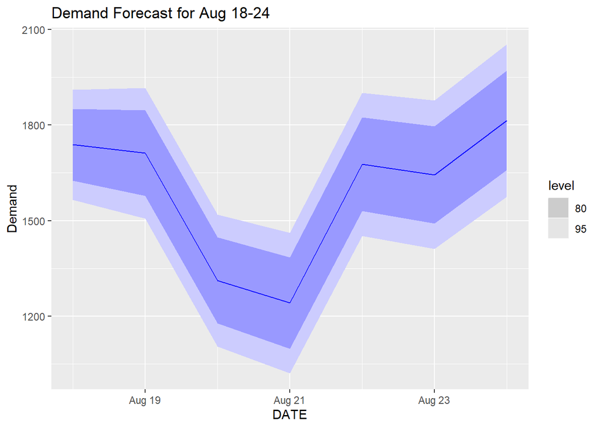

5. (10 pt.) What is your recommendation for your manager regarding the tour operator block? Should your manager sell the block of 60 rooms at a discounted price? Justify your answer.